# House Price Prediction: Measuring the Effect of Data Preprocessing.

In this notebook, we will use a popular competition dataset from Kaggle to highlight the effectiveness of preprocessing data before using it to build a machine learning model. The dataset includes 79 exploratory variables that describe different aspects of houses and a single target variable: the price of the house. Check out the competition here: https://www.kaggle.com/competitions/house-prices-advanced-regression-techniques.

Let's start by importing the the libraries we will use and loading the dataset in pandas DataFrames.

```python
# import libraries:
import os
import sys
from copy import deepcopy
import pandas as pd
import numpy as np
import matplotlib.pyplot as plt
import xgboost
import math
from sklearn.neighbors import KernelDensity, KNeighborsClassifier, KNeighborsRegressor
from scipy.stats import norm

# load the dataset into pandas dataframes:
train_table = pd.read_csv(os.path.join(os.path.dirname(sys.path[0]), "House_Price_Prediction/train.csv"), header=0, index_col=0)
#num_training = len(train_table.index)
test_table = pd.read_csv(os.path.join(os.path.dirname(sys.path[0]), "House_Price_Prediction/test.csv"), header=0, index_col=0)

# separate target features from input features:
target_table = train_table["SalePrice"]
train_table.drop(columns={"SalePrice"}, inplace=True)
```

Let's make sure our tables are formatted correctly.

```python
target_table
```

```
Id
1       208500
2       181500
3       223500
4       140000
5       250000
         ...
1456    175000
1457    210000
1458    266500
1459    142125
1460    147500
Name: SalePrice, Length: 1460, dtype: int64
```

```python
train_table
```

| Id | MSSubClass | MSZoning | LotFrontage | LotArea | Street | Alley | LotShape | LandContour | Utilities | LotConfig | ... | ScreenPorch | PoolArea | PoolQC | Fence | MiscFeature | MiscVal | MoSold | YrSold | SaleType | SaleCondition |
| --- | --- | --- | --- | --- | --- | --- | --- | --- | --- | --- | --- | --- | --- | --- | --- | --- | --- | --- | --- | --- | --- |
| 1 | 60 | RL | 65.0 | 8450 | Pave | NaN | Reg | Lvl | AllPub | Inside | ... | 0 | 0 | NaN | NaN | NaN | 0 | 2 | 2008 | WD | Normal |
| 2 | 20 | RL | 80.0 | 9600 | Pave | NaN | Reg | Lvl | AllPub | FR2 | ... | 0 | 0 | NaN | NaN | NaN | 0 | 5 | 2007 | WD | Normal |
| 3 | 60 | RL | 68.0 | 11250 | Pave | NaN | IR1 | Lvl | AllPub | Inside | ... | 0 | 0 | NaN | NaN | NaN | 0 | 9 | 2008 | WD | Normal |
| 4 | 70 | RL | 60.0 | 9550 | Pave | NaN | IR1 | Lvl | AllPub | Corner | ... | 0 | 0 | NaN | NaN | NaN | 0 | 2 | 2006 | WD | Abnorml |
| 5 | 60 | RL | 84.0 | 14260 | Pave | NaN | IR1 | Lvl | AllPub | FR2 | ... | 0 | 0 | NaN | NaN | NaN | 0 | 12 | 2008 | WD | Normal |
| ... | ... | ... | ... | ... | ... | ... | ... | ... | ... | ... | ... | ... | ... | ... | ... | ... | ... | ... | ... | ... | ... |
| 1456 | 60 | RL | 62.0 | 7917 | Pave | NaN | Reg | Lvl | AllPub | Inside | ... | 0 | 0 | NaN | NaN | NaN | 0 | 8 | 2007 | WD | Normal |
| 1457 | 20 | RL | 85.0 | 13175 | Pave | NaN | Reg | Lvl | AllPub | Inside | ... | 0 | 0 | NaN | MnPrv | NaN | 0 | 2 | 2010 | WD | Normal |
| 1458 | 70 | RL | 66.0 | 9042 | Pave | NaN | Reg | Lvl | AllPub | Inside | ... | 0 | 0 | NaN | GdPrv | Shed | 2500 | 5 | 2010 | WD | Normal |
| 1459 | 20 | RL | 68.0 | 9717 | Pave | NaN | Reg | Lvl | AllPub | Inside | ... | 0 | 0 | NaN | NaN | NaN | 0 | 4 | 2010 | WD | Normal |
| 1460 | 20 | RL | 75.0 | 9937 | Pave | NaN | Reg | Lvl | AllPub | Inside | ... | 0 | 0 | NaN | NaN | NaN | 0 | 6 | 2008 | WD | Normal |

1460 rows × 79 columns

```python
test_table
```

| Id | MSSubClass | MSZoning | LotFrontage | LotArea | Street | Alley | LotShape | LandContour | Utilities | LotConfig | ... | ScreenPorch | PoolArea | PoolQC | Fence | MiscFeature | MiscVal | MoSold | YrSold | SaleType | SaleCondition |
| --- | --- | --- | --- | --- | --- | --- | --- | --- | --- | --- | --- | --- | --- | --- | --- | --- | --- | --- | --- | --- | --- |
| 1461 | 20 | RH | 80.0 | 11622 | Pave | NaN | Reg | Lvl | AllPub | Inside | ... | 120 | 0 | NaN | MnPrv | NaN | 0 | 6 | 2010 | WD | Normal |
| 1462 | 20 | RL | 81.0 | 14267 | Pave | NaN | IR1 | Lvl | AllPub | Corner | ... | 0 | 0 | NaN | NaN | Gar2 | 12500 | 6 | 2010 | WD | Normal |
| 1463 | 60 | RL | 74.0 | 13830 | Pave | NaN | IR1 | Lvl | AllPub | Inside | ... | 0 | 0 | NaN | MnPrv | NaN | 0 | 3 | 2010 | WD | Normal |
| 1464 | 60 | RL | 78.0 | 9978 | Pave | NaN | IR1 | Lvl | AllPub | Inside | ... | 0 | 0 | NaN | NaN | NaN | 0 | 6 | 2010 | WD | Normal |
| 1465 | 120 | RL | 43.0 | 5005 | Pave | NaN | IR1 | HLS | AllPub | Inside | ... | 144 | 0 | NaN | NaN | NaN | 0 | 1 | 2010 | WD | Normal |
| ... | ... | ... | ... | ... | ... | ... | ... | ... | ... | ... | ... | ... | ... | ... | ... | ... | ... | ... | ... | ... | ... |
| 2915 | 160 | RM | 21.0 | 1936 | Pave | NaN | Reg | Lvl | AllPub | Inside | ... | 0 | 0 | NaN | NaN | NaN | 0 | 6 | 2006 | WD | Normal |
| 2916 | 160 | RM | 21.0 | 1894 | Pave | NaN | Reg | Lvl | AllPub | Inside | ... | 0 | 0 | NaN | NaN | NaN | 0 | 4 | 2006 | WD | Abnorml |
| 2917 | 20 | RL | 160.0 | 20000 | Pave | NaN | Reg | Lvl | AllPub | Inside | ... | 0 | 0 | NaN | NaN | NaN | 0 | 9 | 2006 | WD | Abnorml |
| 2918 | 85 | RL | 62.0 | 10441 | Pave | NaN | Reg | Lvl | AllPub | Inside | ... | 0 | 0 | NaN | MnPrv | Shed | 700 | 7 | 2006 | WD | Normal |
| 2919 | 60 | RL | 74.0 | 9627 | Pave | NaN | Reg | Lvl | AllPub | Inside | ... | 0 | 0 | NaN | NaN | NaN | 0 | 11 | 2006 | WD | Normal |

1459 rows × 79 columns

The tables are already formatted well which is convenient, however, there are clearly some missing values. Let's check how many of the columns are missing values.

```python
print(sum(pd.isna(pd.concat([train_table,test_table],axis=0)).any()))
```

```
34
```

Almost half of the features have at least one record with NaN. Let's first take a lazy approach to dealing with these missing values and replace all of the NaN values with 0 if they are continuous or "None" if they are not.

```python
train_table[train_table.select_dtypes("number").columns] = train_table[train_table.select_dtypes("number").columns].fillna(0)
train_table[train_table.select_dtypes("object").columns] = train_table[train_table.select_dtypes("object").columns].fillna("None")
test_table[test_table.select_dtypes("number").columns] = test_table[test_table.select_dtypes("number").columns].fillna(0)
test_table[test_table.select_dtypes("object").columns] = test_table[test_table.select_dtypes("object").columns].fillna("None")
```

Let's make sure that we have filled in all of the missing values:

```python
print(sum(pd.isna(pd.concat([train_table,test_table],axis=0)).any()))
```

```
0
```

Now let's see how well we can train a model to predict our target price from this data. First we one-hot encode the categorical features from our dataset, making sure to combine the tables of training and test input to account for all recorded combinations of categorical variables. Then we separate the datasets and make sure they all have the expected shape.

```python
encoded_table = pd.get_dummies(pd.concat([train_table,test_table],axis=0))
encoded_train_table, encoded_test_table = encoded_table.iloc[:len(target_table)], encoded_table.iloc[len(target_table):]
print(encoded_train_table.shape)
print(encoded_test_table.shape)
print(target_table.shape)
```

```
(1460, 310)
(1459, 310)
(1460,)
```

The shapes of the datasets look good. We are ready to model the data. To build our regression model, we use the XGBoost library. Using a gradient boosted tree for regression is a great option if your input variables include a substantial amount of categorical data. This is because the trees resemble step functions and are able to more closely resemble the underlying distribution of the input data than many continuous functions. Also, they're fast to train and have very approachable APIs. Let's convert our dataframes to type numpy.ndarray and define our model.

```python
targets = target_table.to_numpy()
train_input = encoded_train_table.to_numpy()
test_input = encoded_test_table.to_numpy()

regressor = xgboost.XGBRegressor(n_estimators=1000, learning_rate = 0.01, max_depth = 10, min_child_weight=1, colsample_bytree=0.25, max_bin=20000,
                subsample=0.5, max_leaves = 0, reg_alpha = 0.1, reg_lambda = 0.1, eval_metric = "rmse", gpu_id=0, tree_method = "gpu_hist", random_state=1)
```

Now let's normalize our dataset and train the model to make sure it works. We'll do a small cross validation evaluation as part of that check.

```python
# define cross validation amount:
num_cvs = 15 # we'll do fifteen folds. This will produce a low amount of variance in the cross validation results
cv_size = int(len(train_input)/num_cvs)
log_likelihood = 0

# randomize the training input to ensure consistency:
permutation = np.random.permutation(len(train_input))
cv_input = train_input[permutation]
cv_targets = targets[permutation]

for n in range(num_cvs):
    # split the dataset into training and cross validation sets:
    if n == num_cvs-1:
        cv_train_input, cv_test_input = cv_input[:-cv_size], cv_input[-cv_size:]
        cv_train_targets, cv_test_targets = cv_targets[:-cv_size], cv_targets[-cv_size:]
    else:
        cv_train_input, cv_test_input = np.concatenate([cv_input[:cv_size*n], cv_input[cv_size*(n+1):]], axis=0), cv_input[cv_size*n:cv_size*(n+1)]
        cv_train_targets, cv_test_targets = np.concatenate([cv_targets[:cv_size*n], cv_targets[cv_size*(n+1):]], axis=0), cv_targets[cv_size*n:cv_size*(n+1)]

    # normalize the inputs
    stds = np.round(np.std(cv_train_input, axis = 0), 12) # compute standard deviations of the features
    indices = np.squeeze(np.nonzero(stds)).tolist() # here we remove features with zero standard deviation as they add no information.
    # we apply standardization
    sample_scalars = 1/stds[indices]
    sample_shifters = -np.mean(cv_train_input[:,indices],axis=0) * sample_scalars
    cv_train_input = cv_train_input[:,indices] * sample_scalars + sample_shifters
    cv_test_input = cv_test_input[:,indices] * sample_scalars + sample_shifters

    # log the target outputs. The competition metric measures the squared distance between output and target in log space. The metric is called rmsle.
    cv_train_targets = np.log(cv_train_targets)
    cv_test_targets = np.log(cv_test_targets)

    # train the model
    regressor.fit(cv_train_input, cv_train_targets)

    log_likelihood += -math.sqrt(np.sum((regressor.predict(cv_test_input)-cv_test_targets)**2)/len(cv_test_targets))

print(f"{num_cvs}-fold cross validation log-likelihood: {log_likelihood/num_cvs}.")
```

```
15-fold cross validation log-likelihood: -0.12105878421618965.
```

Now that the model works, we should optimize the hyperparameters to find the best fitting model. The most common ways to go about tuning model hyperparameters are with an exhaustive gridsearch algorithm or with a bayesian-style search. I've written my own little algorithm that incorporates both and you can find examples of me using it on my git-hub. Unfortunatley, explaining it is beyond the scope of this notebook, so I will just paste the best set of hyperparameters I could find:

n_estimators: 2750, learning_rate: 0.015234375, max_depth: 3, max_bin: 40, subsample: 0.5, reg_alpha: 0.125, reg_lambda: 2.5e-05, colsample_bytree=0.273847

Now lets train the model with all of our un-processed training data and see how it scores on Kaggle.

```python
# define the model with optimized hyperparameters
regressor = xgboost.XGBRegressor(n_estimators=2750, learning_rate = 0.015234375, max_depth = 3, min_child_weight=1, colsample_bytree=0.273847, max_bin=40,
            subsample=0.5, max_leaves = 0, reg_alpha = 0.125, reg_lambda = 2.5e-05, eval_metric = "rmse", gpu_id=0, tree_method = "gpu_hist", random_state=1)

# normalize the inputs
stds = np.round(np.std(train_input, axis = 0), 12) # compute standard deviations of the features
indices = np.squeeze(np.nonzero(stds)).tolist() # here we remove features with zero standard deviation as they add no information.
# apply standardization
sample_scalars = 1/stds[indices]
sample_shifters = -np.mean(train_input[:,indices],axis=0) * sample_scalars
final_train_input = train_input[:,indices] * sample_scalars + sample_shifters
final_test_input = test_input[:,indices] * sample_scalars + sample_shifters

# log the target outputs. The competition metric measures the squared distance between output and target in log space. The metric is called rmsle.
log_targets = np.log(targets)

# train the model
regressor.fit(final_train_input, log_targets)

# make predictions
predictions = np.exp(regressor.predict(final_test_input)).tolist()

# save the predictions for Kaggle submission
filename = "submission.csv"
Ids = list(range(1461, 1461+len(predictions)))
table = pd.DataFrame({"Id" : Ids, "SalePrice" : predictions})
table.to_csv(filename, index=False)
```

let's load our datasets again, this time combining the training and testing samples so that any changes we make affect both sets of data. The first thing we will do is look at a few qualities of the data, including the datatypes of each variable, the number of distinct values of each variable, the presence of NaN values, and the minimum and maximum values of continuous variables:

```python
# load the dataset into pandas dataframes:
train_table = pd.read_csv(os.path.join(os.path.dirname(sys.path[0]), "House_Price_Prediction/train.csv"), header=0, index_col=0)
test_table = pd.read_csv(os.path.join(os.path.dirname(sys.path[0]), "House_Price_Prediction/test.csv"), header=0, index_col=0)

# separate target features from input features:
target_table = train_table["SalePrice"]
train_table.drop(columns={"SalePrice"}, inplace=True)

# combine training and test samples
num_training_samples = len(train_table.index) # will use this later to separate train and test samples
input_table = pd.concat([train_table, test_table], axis=0)
inspection_table = pd.DataFrame(index=input_table.columns, data={'dtype':input_table.dtypes, "count_distinct":input_table.nunique(),
    "NaN?":pd.isna(input_table).any(),"min":input_table.min(), "max":input_table.max()})

with pd.option_context('display.max_rows', None, 'display.max_columns', None): # show all records
    print(inspection_table)
```

```
                 dtype  count_distinct   NaN?      min      max
MSSubClass       int64              16  False       20      190
MSZoning        object               5   True      NaN      NaN
LotFrontage    float64             128   True     21.0    313.0
LotArea          int64            1951  False     1300   215245
Street          object               2  False     Grvl     Pave
Alley           object               2   True      NaN      NaN
LotShape        object               4  False      IR1      Reg
LandContour     object               4  False      Bnk      Lvl
Utilities       object               2   True      NaN      NaN
LotConfig       object               5  False   Corner   Inside
LandSlope       object               3  False      Gtl      Sev
Neighborhood    object              25  False  Blmngtn  Veenker
Condition1      object               9  False   Artery     RRNn
Condition2      object               8  False   Artery     RRNn
BldgType        object               5  False     1Fam   TwnhsE
HouseStyle      object               8  False   1.5Fin     SLvl
OverallQual      int64              10  False        1       10
OverallCond      int64               9  False        1        9
YearBuilt        int64             118  False     1872     2010
YearRemodAdd     int64              61  False     1950     2010
RoofStyle       object               6  False     Flat     Shed
RoofMatl        object               8  False  ClyTile  WdShngl
Exterior1st     object              15   True      NaN      NaN
Exterior2nd     object              16   True      NaN      NaN
MasVnrType      object               4   True      NaN      NaN
MasVnrArea     float64             444   True      0.0   1600.0
ExterQual       object               4  False       Ex       TA
ExterCond       object               5  False       Ex       TA
Foundation      object               6  False   BrkTil     Wood
BsmtQual        object               4   True      NaN      NaN
BsmtCond        object               4   True      NaN      NaN
BsmtExposure    object               4   True      NaN      NaN
BsmtFinType1    object               6   True      NaN      NaN
BsmtFinSF1     float64             991   True      0.0   5644.0
BsmtFinType2    object               6   True      NaN      NaN
BsmtFinSF2     float64             272   True      0.0   1526.0
BsmtUnfSF      float64            1135   True      0.0   2336.0
TotalBsmtSF    float64            1058   True      0.0   6110.0
Heating         object               6  False    Floor     Wall
```

[output cut: 25 more lines]

```
PavedDrive      object               3  False        N        Y
WoodDeckSF       int64             379  False        0     1424
OpenPorchSF      int64             252  False        0      742
EnclosedPorch    int64             183  False        0     1012
3SsnPorch        int64              31  False        0      508
ScreenPorch      int64             121  False        0      576
PoolArea         int64              14  False        0      800
PoolQC          object               3   True      NaN      NaN
Fence           object               4   True      NaN      NaN
MiscFeature     object               4   True      NaN      NaN
MiscVal          int64              38  False        0    17000
MoSold           int64              12  False        1       12
YrSold           int64               5  False     2006     2010
SaleType        object               9   True      NaN      NaN
SaleCondition   object               6  False  Abnorml  Partial
```

This view of the dataset allows us to see a few things. First, according to the description of the dataset on Kaggle, the variable "MSSubClass" should really be a categorical variable, not continuous. We will change its dtype from "int64" to "object". Next, it looks like the variables "BsmtFullBath", "BsmtHalfBath", and "GarageCars", which are of type "float64" take on integer values only and could be converted to type "in64". Let's check to make sure.

```python
print(input_table["BsmtFullBath"].unique())
print(input_table["BsmtHalfBath"].unique())
print(input_table["GarageCars"].unique())
```

```
[ 1.  0.  2.  3. nan]
[ 0.  1.  2. nan]
[ 2.  3.  1.  0.  4.  5. nan]
```

They do take on integer values only, so we will convert these variables from "float64" to "int64". Furthermore, in the description of the dataset on Kaggle, several of the categorical variables are supposed to take on NaN values as it indicates that the aspect of the house which the variable represents is missing. We will fill these NaN values with None to avoid confusing them with actual missing data. We will also fill in the corresponding continuous variables with 0 along these records.

```python
for feature in ["MSSubClass"]: # convert features to object/categorical dtype
    input_table[feature] = input_table[feature].astype("object", copy=False)
for feature in ["GarageCars", "BsmtHalfBath", "BsmtFullBath"]: # convert features to int
    input_table[feature] = input_table[feature].astype("Int64", copy=False)

# convert int64 to Int64
input_table[list(input_table.select_dtypes(["int64"]).columns)] = input_table.select_dtypes(["int64"]).astype("Int64")

# fill in categorical NaN values that really represent "None"
for column_name in ["Alley", "MasVnrType", "BsmtQual", "BsmtCond", "BsmtExposure", "BsmtFinType1", "BsmtFinType2", "FireplaceQu", "GarageType", "GarageFinish", "GarageQual", "GarageCond", "PoolQC", "Fence", "MiscFeature"]:
    input_table[column_name].fillna("None", inplace=True)

# fill in corresponding continuous values that should be 0.
input_table.loc[input_table["MasVnrType"]=="None", "MasVnrArea"] = 0
input_table.loc[input_table["BsmtQual"]=="None", ["BsmtFinSF1", "BsmtFinSF2", "BsmtUnfSF", "TotalBsmtSF", "BsmtFullBath", "BsmtHalfBath"]] = 0
input_table.loc[input_table["GarageType"]=="None", ["GarageYrBlt", "GarageCars"]] = 0
input_table.loc[input_table["FireplaceQu"]=="None", "Fireplaces"] = 0
input_table.loc[input_table["PoolQC"]=="None", "PoolArea"] = 0
input_table.loc[input_table["MiscFeature"]=="None", "MiscVal"] = 0
```

The next preprocessing step we will take is to ensure that the records are consistent along related variables. This step is dataset dependent and involves adjusting the values of records for which related variables do not match or make sense. For this dataset, we will make the following adjustments:  
1.) If the variable "MasVnrArea" is 0, then the variable "MasVnrType" must be "None" and vice versa.  
2.) If the variable "TotalBsmtSF" is 0, then the variables "BsmtQual", "BsmtCond", "BsmtExposure", "BsmtFinType1", and "BsmtFinType2" must be "None" and "BsmtFinSF1", "BsmtFinSF2", "BsmtUnfSF", "BsmtFullBath" and "BsmtHalfBath" must be 0.  
3.) If "Fireplaces" is 0, then "FireplaceQu" must be None.  
4.) If "GarageArea" is 0, then "GarageType", "GarageFinish", "GarageQual", and "GarageCond" must be "None" and "GarageYrBlt" and "GarageCars", must be 0.  
5.) If "PoolArea" is 0, then "PoolQC" must be "None".  
6.) If "MiscVal" is 0, then "MiscFeature" must be "None".  
7.) The variable "GarageYrBlt" must be greater than or equal to "YearBlt" and less than or equal to "YrSold".  
8.) The variable "YearRemodAdd" must be greater than or equal to "YearBlt" and less than or equal to "YrSold".  
There may be other noteworthy conditions not covered here, but these will help to clean up some records. It is important not to over-analyze the relationships between variables as over-cleaning the records may cause you to lose important information.

```python
input_table.loc[input_table["MasVnrArea"]==0, "MasVnrType"] = "None"
input_table.loc[input_table["TotalBsmtSF"]==0, ["BsmtQual", "BsmtCond", "BsmtExposure", "BsmtFinType1", "BsmtFinType2"]] = "None"
input_table.loc[input_table["TotalBsmtSF"]==0, ["BsmtFinSF1", "BsmtFinSF2", "BsmtUnfSF", "TotalBsmtSF", "BsmtFullBath", "BsmtHalfBath"]] = 0
input_table.loc[input_table["Fireplaces"]==0, "FireplaceQu"] = "None"
input_table.loc[input_table["GarageArea"]==0, ["GarageType", "GarageFinish", "GarageQual", "GarageCond"]] = "None"
input_table.loc[input_table["GarageArea"]==0, ["GarageYrBlt", "GarageCars"]] = 0
input_table.loc[input_table["PoolArea"]==0, "PoolQC"] = "None"
input_table.loc[input_table["MiscVal"]==0, "MiscFeature"] = "None"

input_table.loc[(input_table["GarageYrBlt"]!=0) & (input_table["GarageYrBlt"]<input_table["YearBuilt"]), "GarageYrBlt"] = input_table["YearBuilt"]
input_table.loc[(input_table["GarageYrBlt"]!=0) & (input_table["GarageYrBlt"]>input_table["YrSold"]), "GarageYrBlt"] = input_table["YrSold"]
input_table.loc[input_table["YearRemodAdd"] < input_table["YearBuilt"], "YearRemodAdd"] = input_table["YearBuilt"]
input_table.loc[input_table["YearRemodAdd"] > input_table["YrSold"], "YearRemodAdd"] = input_table["YrSold"]
input_table.columns[pd.isna(input_table).any()] # see which variables still have missing values
```

```
Index(['MSZoning', 'LotFrontage', 'Utilities', 'Exterior1st', 'Exterior2nd',
       'Electrical', 'KitchenQual', 'Functional', 'GarageYrBlt', 'GarageCars',
       'GarageArea', 'SaleType'],
      dtype='object')
```

There are still some missing values. What we would like to do is fill these missing values with the most likely replacement. To find the most likely values, we will consider not only the variable we are filling, but also the values of every other variable for those records as well. That is, we will fill the remaining missing values with the expected value of the maximum likelihood estimated conditional distribution of each variable given the others.

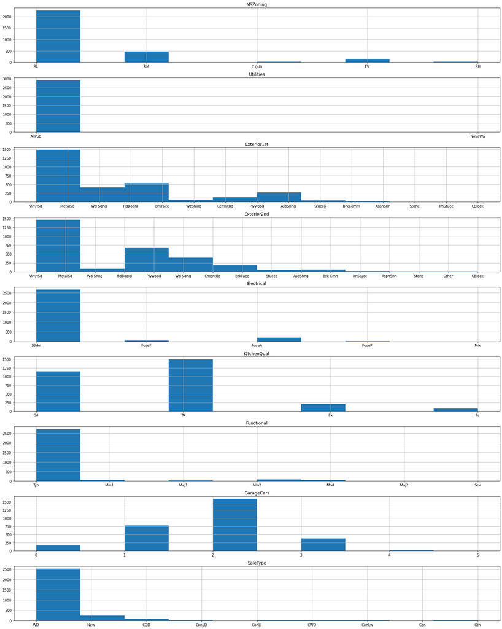

```python
categorical_variables = ['MSZoning', 'Utilities', 'Exterior1st', 'Exterior2nd', 'Electrical', 'KitchenQual', 'Functional', 'GarageCars', 'SaleType']
fig=plt.figure(figsize=(20,25))
for i, var_name in enumerate(categorical_variables):
    ax=fig.add_subplot(9,1,i+1)
    input_table[var_name].hist(ax=ax)
    ax.set_title(var_name)

fig.tight_layout()  # Improves appearance a bit.
plt.show()
```

We still need to estimate the distribution of the following continuous features. First, we will see if they appear normally distributed since that would be most convenient. If they do not appear normally distributed, then we will proceed to estimate their distribution using nonparametric kernel density estimators.

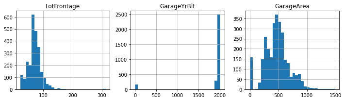

```python
continuous_variables = ['LotFrontage', 'GarageYrBlt','GarageArea']
fig=plt.figure(figsize=(10,3))
for i, var_name in enumerate(continuous_variables):
    ax=fig.add_subplot(1,3,i+1)
    input_table[var_name].hist(ax=ax, bins=30)
    ax.set_title(var_name)

fig.tight_layout()
plt.show()
```

Unfortunately, these distributions are influenced by the presence of zeros corresponding to the absence of that feature on the house. However, we can assume that our filler values for these variables will never be 0 since their corresponding related variables (like "GarageType" for "GarageYrBlt" and "GarageArea") cannot be "None" along the records we are filling, otherwise we would have already filled in these missing values with zeros. Hence, we can ignore the zero values.

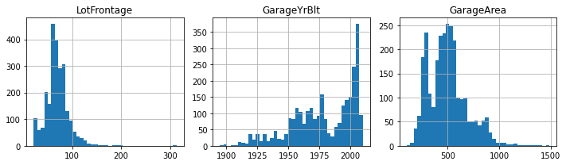

```python
continuous_variables = ['LotFrontage', 'GarageYrBlt','GarageArea']
fig=plt.figure(figsize=(10,3))
for i, var_name in enumerate(continuous_variables):
    ax=fig.add_subplot(1,3,i+1)
    input_table[var_name][input_table[var_name] != 0].hist(ax=ax, bins=40)
    ax.set_title(var_name)

fig.tight_layout()
plt.show()
```

These distributions look better, let's try transforming them in hopes of narrowing the distributions. We'll use a log transform.

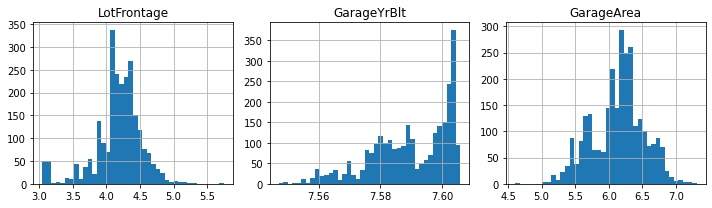

```python
continuous_variables = ['LotFrontage', 'GarageYrBlt','GarageArea']
fig=plt.figure(figsize=(10,3))
for i, var_name in enumerate(continuous_variables):
    ax=fig.add_subplot(1,3,i+1)
    np.log(input_table[var_name][input_table[var_name] != 0]).hist(ax=ax, bins=40)
    ax.set_title(var_name)

fig.tight_layout()
plt.show()
```

The variable "GarageArea" looks like it can be reasonably estimated with a normal distribution, but "LotFrontage" and "GarageYrBlt" have too much weight in their tails. We will use kernel density estimates for these two variables. In order to find good bandwidths for our kernel density estimates, we use ten-fold cross validation and adjust the bandwidth value for each distribution estimate until we maximize the cross validated log-likelihood. Doing this yields the following estimates:

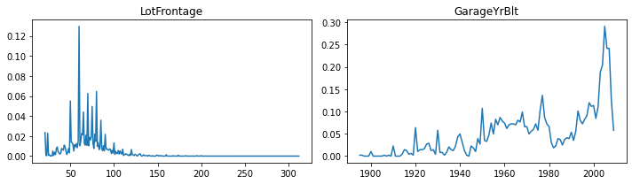

```python
fig=plt.figure(figsize=(10,3))

# build kernel density estimates:
samples = input_table["LotFrontage"][input_table["LotFrontage"].notnull()].to_numpy()
distribution = KernelDensity(bandwidth=0.35)
distribution.fit(samples[:,None])
ax=fig.add_subplot(1,2,1)
x = np.array(range(int(np.min(samples)), int(np.max(samples))))
ax.plot(x, np.exp(distribution.score_samples(x[:,None])))
ax.set_title("LotFrontage")

samples = input_table["GarageYrBlt"][input_table["GarageYrBlt"].notnull() & (input_table["GarageYrBlt"]!=0)].to_numpy()
distribution = KernelDensity(bandwidth=0.07)
distribution.fit(samples[:,None])
ax=fig.add_subplot(1,2,2)
x = np.array(range(int(np.min(samples)), int(np.max(samples))))
ax.plot(x, np.exp(distribution.score_samples(x[:,None])))
ax.set_title("GarageYrBlt")

fig.tight_layout()
plt.show()
```

If you're wondering how these jagged distributions can possibly be best fitting, remember that the variables only take on discrete values, so it makes sense that their distributions might resemble categorical distributions. In fact, you could probably estimate the distributions of these variables using categorical distributions and see little difference in the results.

Now that we have our distribution estimates, we are going to temporarily fill in the missing values of each variable with samples from that variable's estimated distribution.

```python
temporarily_filled_table = deepcopy(input_table)
for variable in input_table.columns[pd.isna(input_table).any()]:
    if variable in {'MSZoning', 'Utilities', 'Exterior1st', 'Exterior2nd', 'Electrical', 'KitchenQual', 'Functional', 'GarageCars', 'SaleType'}:
        samples = np.random.choice(input_table[variable][input_table[variable].notnull()], size = sum(pd.isna(input_table[variable])))
        temporarily_filled_table.loc[pd.isna(input_table[variable]), variable] = samples
    elif variable == "LotFrontage":
        distribution = KernelDensity(bandwidth=0.35)
        distribution.fit(input_table["LotFrontage"][input_table["LotFrontage"].notnull()].to_numpy()[:,None])
        samples = distribution.sample(sum(pd.isna(input_table["LotFrontage"]))).astype("int64")
        temporarily_filled_table.loc[pd.isna(input_table[variable]), variable] = samples
    elif variable == "GarageYrBlt":
        distribution = KernelDensity(bandwidth=0.07)
        distribution.fit(input_table["GarageYrBlt"][input_table["GarageYrBlt"].notnull()].to_numpy()[:,None])
        samples = distribution.sample(sum(pd.isna(input_table["GarageYrBlt"]))).astype("int64")
        temporarily_filled_table.loc[pd.isna(input_table[variable]), variable] = samples
    elif variable == "GarageArea":
        samples = norm.rvs(loc=np.mean(input_table["GarageArea"][input_table["GarageArea"].notnull()].to_numpy()), scale = np.std(input_table["GarageArea"][input_table["GarageArea"].notnull()].to_numpy())).astype("int64")
        temporarily_filled_table.loc[pd.isna(input_table[variable]), variable] = samples
print(sum(pd.isna(input_table).any()))
print(sum(pd.isna(temporarily_filled_table).any()))
```

```
12
0
```

With this temporarily filled table, we are going to iteratively use a simple, nonparametric predictive model to learn the relationships between variables. We will use a K-nearest neighbors algorithm as our predictive model since it is robust and will take much less time to tune for hyperparameters since there is only one (K). We begin by learning to predict the variable with the fewest missing values and work our way towards learning to predict the variable with the most.

```python
# order variables by number of missing values
variables = ['MSZoning', 'LotFrontage', 'Utilities', 'Exterior1st', 'Exterior2nd', 'Electrical', 'KitchenQual', 'Functional', 'GarageYrBlt', 'GarageCars', 'GarageArea', 'SaleType']
missing_values = []
for variable in variables:
    missing_values.append(sum(pd.isna(input_table[variable])))
permutation = np.argsort(missing_values).astype("int64")
variables = np.array(variables)[permutation] # now in order from least missing values to most

ks = [1,2,3,4,5,6,7,8,9,10,15,20,30,40,50,60,75,100] # these are the K values we will cross validate
num_cvs = 10 # using ten folds of cross validation
for variable in variables:
    X = temporarily_filled_table.drop(columns = [variable]) # gets all of the input data except for the variable whose missing values we are filling
    X = pd.get_dummies(X).to_numpy() # one-hot encode and convert to numpy.ndarray
    if variable in {'MSZoning', 'Utilities', 'Exterior1st', 'Exterior2nd', 'Electrical', 'KitchenQual', 'Functional', 'GarageCars', 'SaleType'}:
        y, categories = pd.factorize(temporarily_filled_table[variable]) # if y(target) is categorical, convert categories to labels (0,1,2,...num_categories)
    else: y = temporarily_filled_table[variable].to_numpy()

    variable_results = [] # holds the cross validation results
    for k in range(len(ks)):
        # shuffle the data
        permutation = list(range(0,len(y)))
        inverse_permutation = np.argsort(permutation) # will be used later for converting back to original order
        np.random.shuffle(permutation)
        X = X[permutation]
        y = y[permutation]

        # instantiate cross validation variables
        avg_log_likelihood = 0
        cv_size = int(len(y)/num_cvs)
        for n in range(num_cvs): # separate train and cv sets, train model, predict
            if n == num_cvs-1:
                train_X, test_X = X[:-cv_size], X[-cv_size:]
                train_y, test_y = y[:-cv_size], y[-cv_size:]
            else:
                train_X, test_X = np.concatenate([X[:int(cv_size*n)], X[int(cv_size*(n+1)):]], axis=0), X[int(cv_size*n):int(cv_size*(n+1))]
                train_y, test_y = np.concatenate([y[:int(cv_size*n)], y[int(cv_size*(n+1)):]], axis=0), y[int(cv_size*n):int(cv_size*(n+1))]

            if variable in {'MSZoning', 'Utilities', 'Exterior1st', 'Exterior2nd', 'Electrical', 'KitchenQual', 'Functional', 'GarageCars', 'SaleType'}:
                model = KNeighborsClassifier(ks[k])
                model.fit(train_X, train_y)
                predictions = model.predict(test_X)
                avg_log_likelihood += (np.sum(test_y==predictions)/len(predictions))-1
            else:
                model = KNeighborsRegressor(ks[k])
                model.fit(train_X, train_y)
                predictions = np.round(model.predict(test_X))
                avg_log_likelihood += -np.sum((test_y-predictions)**2)/len(predictions)
        avg_log_likelihood = avg_log_likelihood/num_cvs
        variable_results.append(avg_log_likelihood)

    # choose best K value and retrain model on all the temporary data. Predict missing values and replace them in temporary table
    k = ks[np.argmin(variable_results)]
    if variable in {'MSZoning', 'Utilities', 'Exterior1st', 'Exterior2nd', 'Electrical', 'KitchenQual', 'Functional', 'GarageCars', 'SaleType'}:
        model = KNeighborsClassifier(k)
        model.fit(X, y)
        X = X[inverse_permutation]
        y = y[inverse_permutation]
        samples = X[pd.isna(input_table[variable])]
        predictions = categories[model.predict(samples)]
        input_table.loc[pd.isna(input_table[variable]), variable] = predictions
    else:
        model = KNeighborsRegressor(k)
        model.fit(X, y)
        X = X[inverse_permutation]
        y = y[inverse_permutation]
        samples = X[pd.isna(input_table[variable])]
        predictions = np.round(model.predict(samples))
        input_table.loc[pd.isna(input_table[variable]), variable] = predictions
```

```python
# save the filled tables
input_table.iloc[:len(target_table.index)].to_csv(os.path.join(os.path.dirname(sys.path[0]), "House_Price_Prediction/preprocessed_train.csv"))
input_table.iloc[len(target_table.index):].to_csv(os.path.join(os.path.dirname(sys.path[0]), "House_Price_Prediction/preprocessed_test.csv"))
target_table.to_csv(os.path.join(os.path.dirname(sys.path[0]), "House_Price_Prediction/preprocessed_targets.csv"))
```

All of the missing values have been filled using our iterative imputation method. Now we are ready to re-tune our predictive model. This time around, the best-fitting hyperparameters are only slightly different than they were previously when we trained the model using lazily preprocessed data. Here are the best hyperparameters this time around:

n_estimators: 2812, learning_rate: 0.01425, max_depth: 4, max_bin: 48, subsample: 0.5, reg_alpha: 0.125, reg_lambda: 0, colsample_bytree : 0.25

```python
# load preprocessed datasets
train_samples = pd.read_csv(os.path.join(os.path.dirname(sys.path[0]), "House_Price_Prediction/preprocessed_train.csv"), header=0, index_col=0)
test_samples = pd.read_csv(os.path.join(os.path.dirname(sys.path[0]), "House_Price_Prediction/preprocessed_test.csv"), header=0, index_col=0)
train_targets = pd.read_csv(os.path.join(os.path.dirname(sys.path[0]), "House_Price_Prediction/train.csv"), header=0, index_col=0)["SalePrice"]

# make some final changes
for variable in train_samples.columns:
    if train_samples[variable].dtype == "object":
        train_targets = train_targets[train_samples[variable].isin(test_samples[variable])]
        train_samples = train_samples[train_samples[variable].isin(test_samples[variable])]

# combine train_samples and test_samples to compute one-hot encoded features
train_targets = train_targets.to_numpy().flatten()
input_samples = pd.get_dummies(pd.concat([train_samples, test_samples],axis=0)).to_numpy()
train_samples = input_samples[:len(train_targets)]
test_samples = input_samples[len(train_targets):]

# normalize the inputs
stds = np.round(np.std(train_samples, axis = 0), 12) # compute standard deviations of the features
indices = np.squeeze(np.nonzero(stds)).tolist() # here we remove features with zero standard deviation as they add no information.

# apply standardization
sample_scalars = 1/stds[indices]
sample_shifters = -np.mean(train_samples[:,indices],axis=0) * sample_scalars
final_train_input = train_samples[:,indices] * sample_scalars + sample_shifters
final_test_input = test_samples[:,indices] * sample_scalars + sample_shifters

# log the target outputs. The competition metric measures the squared distance between output and target in log space. The metric is called rmsle.
log_targets = np.log(train_targets)

# define model
hyperparameters = {
    "n_estimators":2812,
    "learning_rate":0.01425,
    "max_depth": 4,
    "max_bin":48,
    "subsample":0.5,
    "reg_alpha":0.125,
    "reg_lambda":0,
    "colsample_bytree" : 0.25
}
regressor = xgboost.XGBRegressor(**hyperparameters, eval_metric = "rmse", gpu_id=0, tree_method = "gpu_hist", random_state=1)

# train the model
regressor.fit(final_train_input, log_targets)

# make predictions
predictions = np.exp(regressor.predict(final_test_input)).tolist()

# save the predictions for Kaggle submission
filename = "submission.csv"
Ids = list(range(1461, 1461+len(predictions)))
table = pd.DataFrame({"Id" : Ids, "SalePrice" : predictions})
table.to_csv(filename, index=False)
```

If you wanted to increase the accuracy of this model further, next steps would include feature-engineering and model ensembling. Through feature-engineering, we would consider ways to adjust variable values and combine variables to create new variables that have imformative influences over the target variable (house price). An example of one such additional variable might be the combination of all square footage measurements to create a total square footage measurement for the house. Ensembling would include training and tuning different kinds of predictive models in addition to the gradient boosted tree used in this notebook, and combining their predictions to make some kind of weighted average. Ensemble methods increase accuracy by reducing the bias that is present when only one type of model is used.

Thanks for following along with this experiment. You can check out some of my other projects here: https://tobibutler.github.io/TobiButler-github.io/.